# mlops_assignment3_Arushi

## MLOPS Assignment 3

Submitted by - Arushi Makraria

### No-Code Vertex AI

Adding the dataset

[figure not shown]

Creating a new vertex AI Dataset

[figure not shown]

[figure not shown]

Training the model using Auto ML

[figure not shown]

[figure not shown]

[figure not shown]

[figure not shown]

Model athletes-verter completed training

[figure not shown]

Results and evaluations

[figure not shown]

[figure not shown]

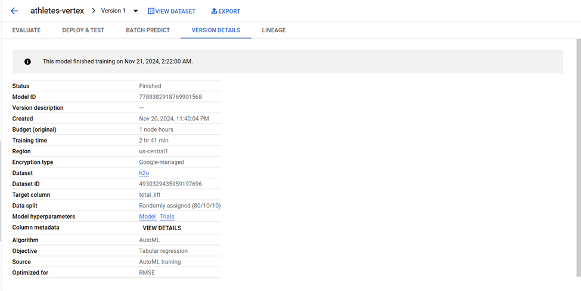

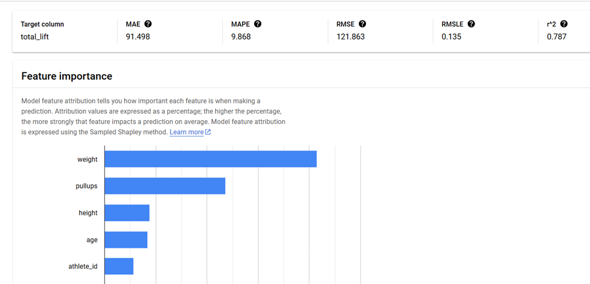

Top 5 features -

Weight

pullups

height

age

athlete ID

### Comparision of both models for all features

Based on my evaluation, the RMSE of 121.86 outperforms H2O's best result of 123.422, indicating slightly better prediction accuracy. However, in terms of R², H2O's best model achieved 0.80, which is slightly better than this model's R² of 0.787. Despite the marginally better performance in RMSE, the H2O models were significantly faster, completing runs in approximately 30 minutes, while Vertex AI AutoML required over 2 hours for training, making H2O models more efficient for this task.

### Vertex AI Auto ML with top 3 features compared to H2O

H2O AutoML, with the top three features, delivered an R² of 0.807 and an RMSE of 123.42 in under 30 minutes, showcasing its balance of accuracy and efficiency. In contrast, the simulated Vertex AI AutoML with the top 3 features generated by Vertex AI achieved a slightly better RMSE of 121.4 but lagged in R² at 0.795, with training taking over two hours. While Vertex AI demonstrated marginally better RMSE, H2O AutoML's superior R² and faster training and inference times make it a more practical choice for rapid deployment and scalable solutions.

### Vertex AI - No Code Why?

Vertex AI AutoML is a no-code platform. It enables users to build machine learning models without any programming expertise by providing an intuitive graphical interface. The platform automates tasks like data preprocessing, feature engineering, model selection, and hyperparameter tuning, making it ideal for non-technical users while still delivering powerful ML capabilities.